# Lecture 2 Probability

2025-01-20

## Bernoulli distribution

Bernoulli distribution is one of the simplest probability distribution.

Ex.

1. Consider tossing a coin, one out of two possible events will occur, head or tail.
2. You go to a casino, one out of two possible will occur, you win or you lost.
3. A random human is being selected and age is recorded, one out of two outcomes will occur, adult or non-adult.

These types of experiment or processes are called Bernoulli trial.

The two event classes and their associated probability probabilities a Bernoulli process.

## Bernoulli probability

In general we call one event in a Bernoulli process a “success” as 1 with probability \(p\), and call the other “failure” as 0 with probability \(q\).

We always have \(q=1-p\)

## Bernoulli distribution

The probability distribution of a Bernoulli variable:

\[ f(x)= \begin{cases} p & x=1\\ q & x=0 \end{cases} \]

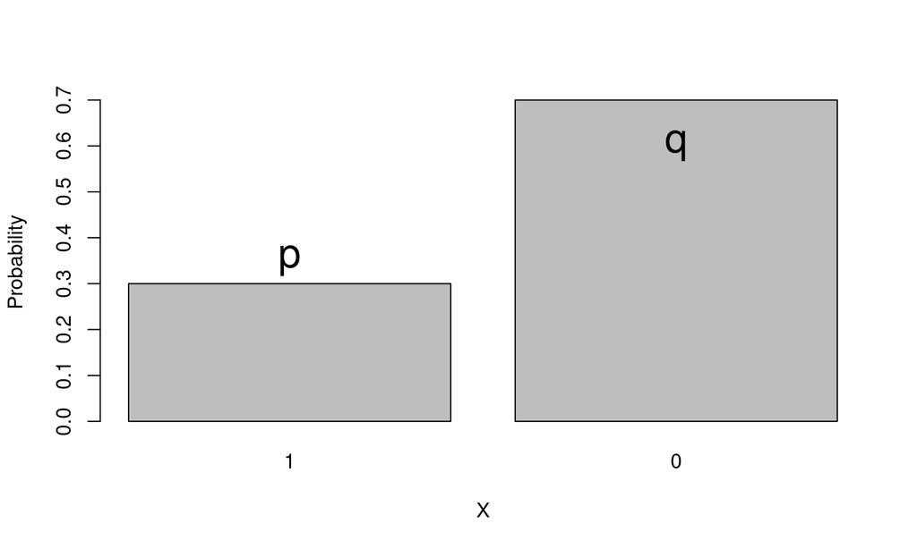

## Bernoulli variable

- Expected value of a Bernoulli variable

\[ \begin{align} E[X] & = \sum_{x=0,1}xp(x) \\ & =1*p + 0*q \\ & =p \end{align} \]

- Variance of Bernoulli variable

\[ \begin{align} Var(X) & = E[X^2]-E[X]^2 \\ & =\sum_{x=0,1}x^2p(x) - p^2 \\ & =p-p^2 \\ & =p(1-p)=pq \end{align} \]

## Binomial Process

If we repeatedly conduct the same Bernoulli experiment \(N\) times, and each repetition is *identical* and *independent*.

- **Identical**
  - each repetition has the same Bernoulli distribution
- **Independent**
  - every repetition has no impact on other repetition

We can think about this process as repeatedly tossing the same coin and record its outcome.

## Binomial Variable

Now, we define a random variable \(X\) as the number of success (1) in \(N\) repetition of a Bernoulli process with success probability \(p\), and failure probability as \(q\). This random variable is called Binomial variable and it has a binomial distribution.

## Binomial probability

Consider \(N=2\)

Outcome \({HH, LL, HL, LH}\)

\[ P(HH) = 1/2 * 1/2 = 1/4 \\ P(HL)= 1/4 \\ P(LH) = 1/4 \\ P(LL) = 1/4 \]

## Binomial probability

For this binomial variable, it has the following probability distribution

\[ p(0) = P(LL) = 1/4 \\ p(1)= P(HL) + P(LH) = 1/2 \\ p(2) = P(HH) = 1/4 \]

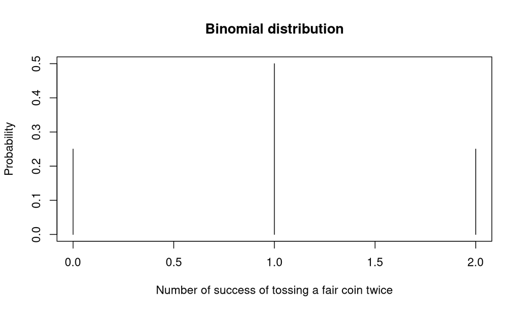

## Binomial Distribution

In the previous lecture, we have learned that if we are tossing a fair coin \(N\) times.

The number of success \(X\) follows a probability distribution \(P(X=k)\)

\[ P(X=k) = {N\choose k}(\frac{1}{2})^N \]

If we are tossing a coin with success probability \(p\) for \(N\) times.

The number of success \(X\) follows a probability distribution \(P(X=k)\)

\[ P(X=k) = {N\choose k}p^k(1-p)^{N-k} \]

## Binomial Variable

For a binomial variable of \(N\) repetition and sucess probability \(p\).

Remember

\[ E[X+Y] = E[X] + E[Y] \]

It has expected value

\[ \begin{align} E[X] & = E[X_1 + X_2 + X_3 + ... + X_N] \\ & = E[X_1] + E[X_2] + ... + E[X_N] \\ & = p + p + p + ... + p = Np \end{align} \]

## Binomial Variable

For a binomial variable of \(N\) repetition and success probability \(p\).

Remember, if \(X\) and \(Y\) are indenpendent

\[ Var(X+Y) = Var(X) + Var(Y) \]

It has variance

\[ \begin{align} Var(X) & = Var(X_1 + X_2 + X_3 + ... + X_N) \\ & = Var(X_1) + Var(X_2) + ... + Var(X_N) \\ & = NVar(X_i) = Np(1-p) \end{align} \]

## Binomial Variable exercise

Tossing a coin with success probability \(p=0.3\) repetitively for \(N=10\) times.

1. What is the probability of getting exactly 5 successes?
2. What is the probability of getting equal or more than 8 successes?
3. What is the probability of getting a number of successes that is more or equal to 3 and less or equal to 7?
4. What is the expected value of number of successes?
5. What is the variance of the number of successes?

## Binomial Variable

If we increase the number of repetition in Binomial variable with success probability \(p\), what will happen?

If we toss a coin (\(p=0.2\)) 10 times, 100 times, 1000 times.

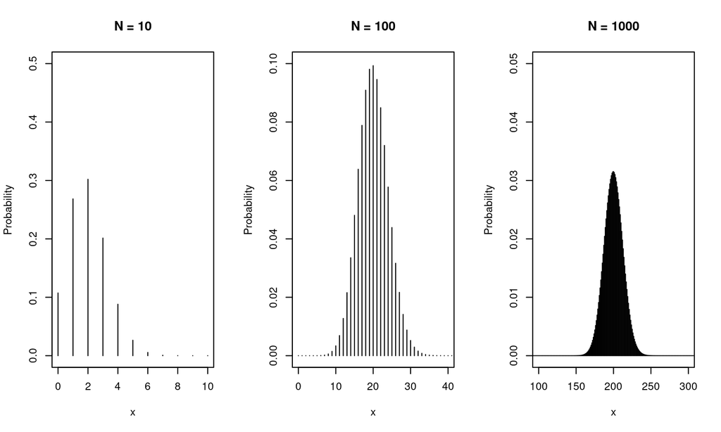

## Galton Board

Lets see an experiment called **Galton Board**

https://www.youtube.com/watch?v=EvHiee7gs9Y

## Normal Variable

One interesting observation is that as \(N \rightarrow \infty\), the binomial distribution will approximate to a continous distribution with \(Np\) as its mean, and \(Np(1-p)\) as its variance.

This distribution is called **normal distribution**.

## Normal Distribution

A normal distribution is defined by two parameters: **Mean** \(\mu\) and **Variance** \(\sigma^2\).

\[ f(x) = \frac{1}{\sigma\sqrt{2\pi}}e^{-\frac{1}{2}(\frac{x-\mu}{\sigma})^2} \]

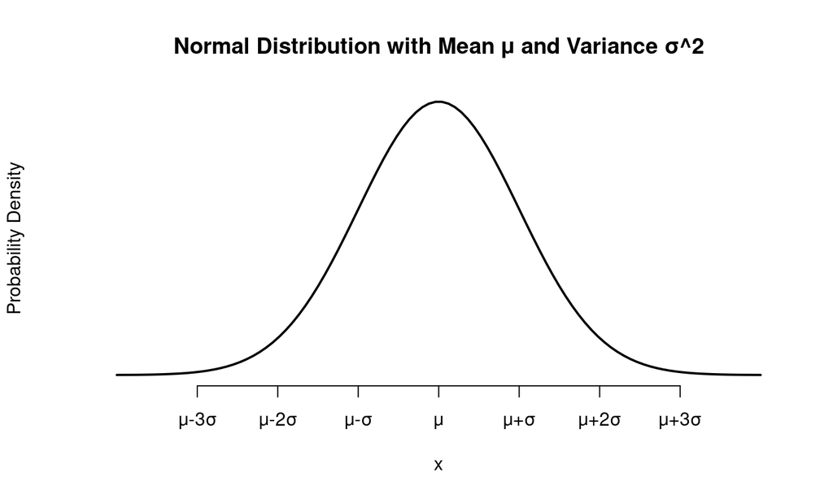

## Normal Distribution

For a random variable \(X\) that follows a normal distribution \(N\), with parameter \(\mu\) and \(\sigma^2\).

We denote it as \(X\sim N(\mu, \sigma^2)\)

Normal distribution is one of the most important distributions in statistics. Many real world data follows a normal distribution such as US adults height, job satisfaction, SAT scores.

But **WHY**?

## Normal Distribution Properties

- A normal distribution with mean \(\mu\) and variance \(\sigma^2\)

\[ E[X] = \mu \\ Var(X) = \sigma^2 \]

## Normal Distribution Properties

- Central Tendency

Normal distribution is unimodal, symmetric, and bell shaped.

**Unimodal**: Has only one mode

**Symmetric**: The probability density function of the left side of its mean is symmetric to the right side.

**Bell Shaped**: Probability density function peaks at its center mean, and drops away from its mean.

Mean = median = mode

## Normal Distribution Properties

- Linear transofmation of a normal distribution

if \(X \sim N(\mu, \sigma^2)\)

\[ aX+b \sim N(a\mu +b, a^2\sigma^2) \]

## Standard Normal Distribution (Z distribution)

Every normal distribution can be considered as a linear transformation from standardized normal distribution.

A standard normal distribution is called \(Z\) distribution

\[ Z = N(0, 1) \] with mean \(\mu = 0\) and variance \(\sigma^2=1\).

\[ Y = \sigma X+\mu \\ X \sim Z = N(0,1) \\ Y \sim N(\mu, \sigma^2) \\ \frac{Y-\mu}{\sigma}\sim N(0,1) \]

## Standard Normal Distribution (Z distribution)

A Z distribution is following a probability density function

\[ f(x) = \frac{1}{\sqrt{2\pi}}e^{-\frac{x^2}{2}} \]

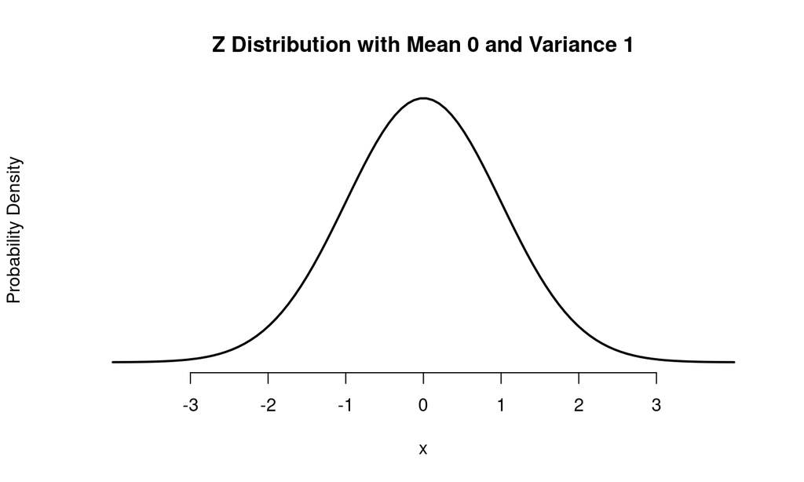

## Normal Distribution Properties

- Linear combination of normal distributed random variables

Any linear combination of independent and normally distributed random variables is normally distributed

if \(X_1, X_2, X_3, ..., X_n\) are indentical and independent distributed

\[ X_i \sim N(\mu, \sigma^2) \\ Y = \sum_{i=1}^{n}X_i \sim N(n\mu, n\sigma^2) \\ E[Y] = n\mu \\ Var[Y] = \sum_{i=1}^{n}Var(X_i) = n\sigma^2 \]

## Central Limit Theorem

Why so many observed data follows a normal distribution?

Central Limit Theorem (CLT)

For a sequence of random variables \(X_1, X_2, X_3, ..., X_n\) to be identical and independently distributed. Each has a mean of \(\mu\) and variance \(\sigma^2\), thus its sample mean \(\bar{X} = \sum_{i}^{n}X_i / n\) follows a normal distribution.

We can consider many observed data as a combination of \(i.i.d\) random variables.

## Chi-squared Distribution

If \(Z_1, Z_2, Z_3, ..., Z_n\) are independent standard normal variables, then \(Y=\sum_{i=1}^{n}Z_i^2\) is said to have a chi-squared distribution \(\chi_n^2\) with parameter degree of freedom as \(n\).

A chi squared distribution \(\chi_n^2\) follows a probability density function \(f(x, n)\).

\[ f(x, n) = \ \begin{cases} \frac{x^{n/2-1}e^{-x/2}}{2^{n/2}\Gamma(n/2)} & x>0\\ 0 & otherwise \end{cases} \\ \Gamma(z)=\int_{0}^{\infty}t^{z-1}e^{-t}dt \]

## Chi-squared Distribution

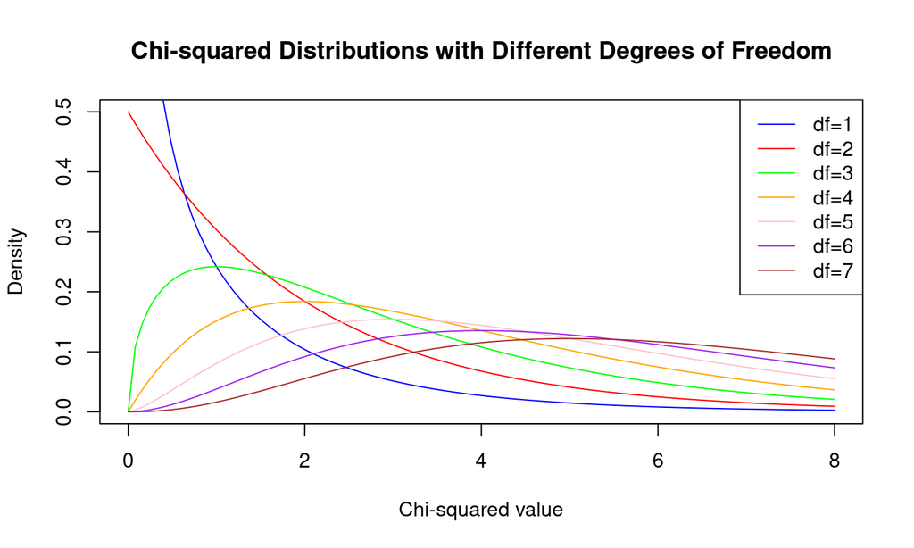

## F Distribution

The F distribution is governed by two degree of freedom parameters \(d_1\) and \(d_2\).

A F distributed variable \(X\) as ratio of two scaled Chi square variables.

\[ X=\frac{U_1/d_1}{U_2/d_2} \\ U_1 \sim \chi_{d_1}^2 \\ U_2 \sim \chi_{d_2}^2 \] where \(U_1\) and \(U_2\) are independent chi squared distribution with degree of freedom \(d_1\) and \(d_2\).

## F Distribution

A F distribution variable \(X\) has the following probability density function \(f(x, d_1, d_2)\) with parameter \(d_1\), \(d_2\).

\[ f(x, d_1, d_2) = \frac{1}{B(\frac{d_1}{2}, \frac{d_2}{2})}(\frac{d_1}{d_2})^{\frac{d_1}{2}}x^{\frac{d_1}{2}-1}(1+\frac{d_1}{d_2}x)^{-\frac{d_1+d_2}{2}} \\ B(a,b) = \int_{0}^{1}t^{a-1}(1-t)^{b-1}dt \]

## F Distribution

[figure not shown]

## Probability Density Function and Cumulative Density Function

Now we have known the probability density function for Normal distribution \(N(\mu,\sigma^2)\), standard normal distribution \(Z\), chi squared distribution \(\chi_k^2\), and F distribution \(F_{d_1,d_2}\)

How do we calculate the probability density, and the probability of \(P(b\leq X\leq a)\)?

## pdf and cdf

We do not calculate!

We use softwares (R or Python) to calculate!

To calculate the probability density \(f(0.5)\) for a normal distributed variable \(X \sim N(1,1)\)

```r
dnorm(0.5, mean=1, sd=1)
```

```
## [1] 0.3520653
```

## pdf and cdf

To calculate the probability density \(f(0.5)\) for a normal distributed variable \(X \sim N(1,1)\)

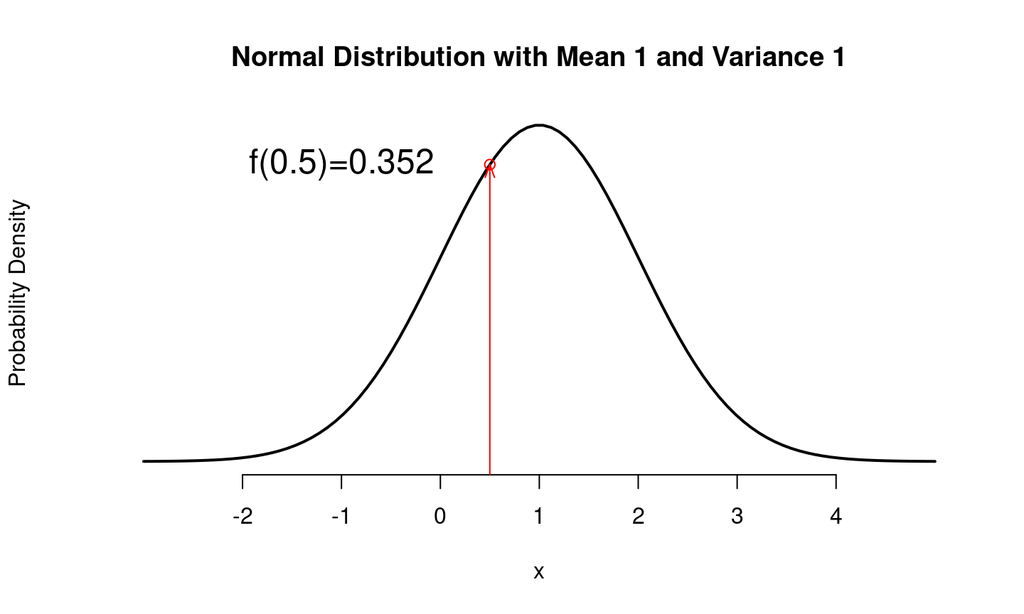

## pdf and cdf

To calculate the cumulative probability \(F(0.5) = P(X\leq 0.5)\) for a normal distributed variable \(X \sim N(1,1)\)

```r
pnorm(0.5, mean=1, sd=1)
```

```
## [1] 0.3085375
```

## pdf and cdf

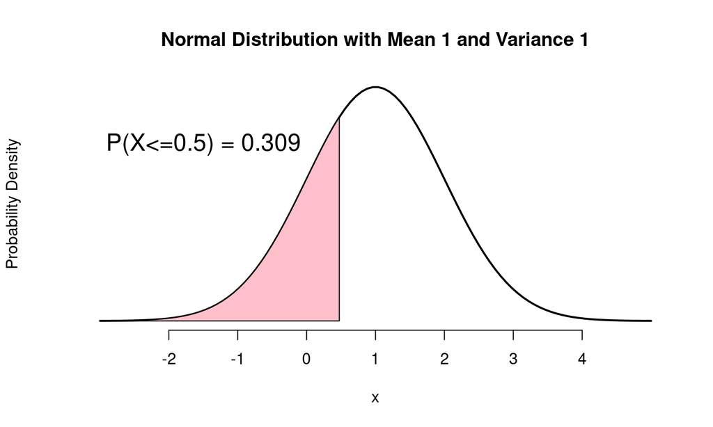

## pdf and cdf

To calculate the probability \(P(X \ge 0.5)\) for a normal distributed variable \(X \sim N(1,1)\)

\[ P(X\ge 0.5) = 1 - P(X<0.5) \]

```r
1-pnorm(0.5, mean=1, sd=1)
```

```
## [1] 0.6914625
```

## pdf and cdf

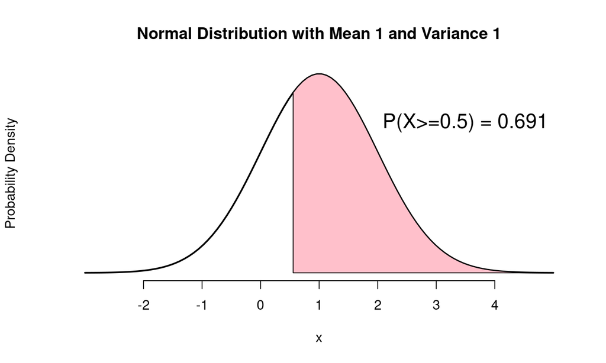

## pdf and cdf

To calculate the probability \(P(-1\le X \le 2)\) for a normal distributed variable \(X \sim N(1,1)\)

\[ P(-1\le X \le 2) = P(X\le 2) - P(X\le -1) \]

```r
pnorm(2, mean=1, sd=1)-pnorm(-1, mean=1, sd=1)
```

```
## [1] 0.8185946
```

## pdf and cdf

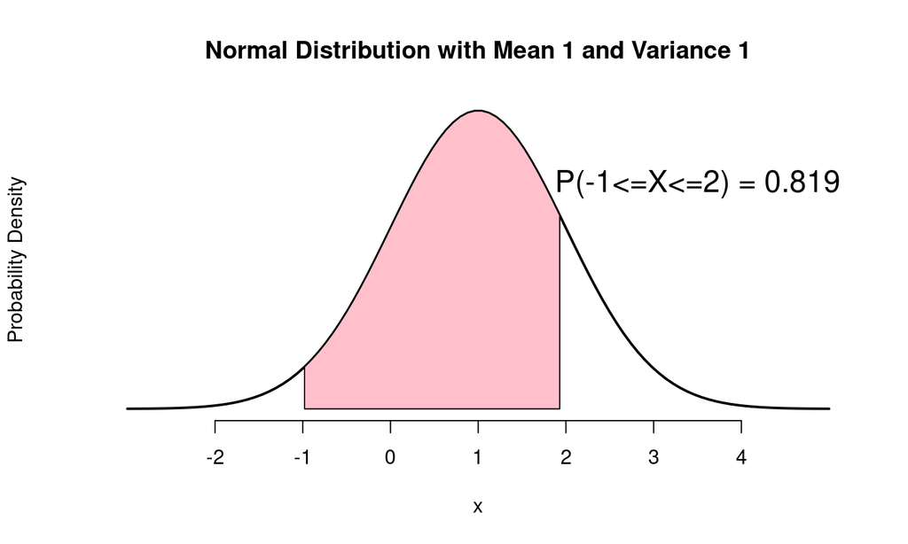

## pdf and cdf

We can follow the same logit to calculate the pdf and probabilities for Chi-squared distributed Variable.

```r
dchisq(0.5, df=1)
```

```
## [1] 0.4393913
```

```r
pchisq(0.5, df=1)
```

```
## [1] 0.5204999
```

## pdf and cdf

We can follow the same logit to calculate the pdf and probabilities for F distributed Variable.

```r
df(0.5, df1=1, df2=10)
```

```
## [1] 0.4207697
```

```r
pf(0.5, df=1, df2=10)
```

```
## [1] 0.5043525
```